# Ford GoBike System Data

## Preliminary Wrangling

> This data set includes information about individual rides made in a bike-sharing system covering the greater San Francisco Bay area. The Bikeshare.com website and platform is owned and managed by Cyclehop, a private bike share company

```python
# import all packages and set plots to be embedded inline
import numpy as np
import pandas as pd
import matplotlib.pyplot as plt
import seaborn as sb

%matplotlib inline
```

> Load in your dataset and describe its properties through the questions below. Try and motivate your exploration goals through this section.

```python
# Load data set
df = pd.read_csv("201902-fordgobike-tripdata.csv")
```

```python
# high-level overview of data shape and composition
df.sample(10)
```

|  | duration_sec | start_time | end_time | start_station_id | start_station_name | start_station_latitude | start_station_longitude | end_station_id | end_station_name | end_station_latitude | end_station_longitude | bike_id | user_type | member_birth_year | member_gender | bike_share_for_all_trip |
| --- | --- | --- | --- | --- | --- | --- | --- | --- | --- | --- | --- | --- | --- | --- | --- | --- |
| 167142 | 626 | 2019-02-04 17:37:53.8750 | 2019-02-04 17:48:19.9350 | 350.0 | 8th St at Brannan St | 37.771431 | -122.405787 | 109.0 | 17th St at Valencia St | 37.763316 | -122.421904 | 4952 | Subscriber | 1989.0 | Male | No |
| 34634 | 283 | 2019-02-23 22:30:45.7940 | 2019-02-23 22:35:29.4220 | 145.0 | 29th St at Church St | 37.743684 | -122.426806 | 386.0 | 24th St at Bartlett St | 37.752105 | -122.419724 | 5360 | Subscriber | 1987.0 | Male | No |
| 20431 | 940 | 2019-02-26 12:31:27.1350 | 2019-02-26 12:47:07.2950 | 139.0 | Garfield Square (25th St at Harrison St) | 37.751017 | -122.411901 | 120.0 | Mission Dolores Park | 37.761420 | -122.426435 | 6106 | Customer | 1994.0 | Male | No |
| 110565 | 678 | 2019-02-12 17:47:48.8430 | 2019-02-12 17:59:07.0140 | 253.0 | Haste St at College Ave | 37.866418 | -122.253799 | 171.0 | Rockridge BART Station | 37.844279 | -122.251900 | 1577 | Subscriber | 1977.0 | Female | Yes |
| 33224 | 4747 | 2019-02-24 11:14:48.7580 | 2019-02-24 12:33:56.1860 | 61.0 | Howard St at 8th St | 37.776513 | -122.411306 | 74.0 | Laguna St at Hayes St | 37.776435 | -122.426244 | 5937 | Subscriber | 1989.0 | Male | No |
| 101781 | 368 | 2019-02-14 17:16:10.8750 | 2019-02-14 17:22:19.8740 | 9.0 | Broadway at Battery St | 37.798572 | -122.400869 | 21.0 | Montgomery St BART Station (Market St at 2nd St) | 37.789625 | -122.400811 | 5246 | Subscriber | NaN | NaN | No |
| 167608 | 638 | 2019-02-04 17:01:52.8680 | 2019-02-04 17:12:31.7730 | 349.0 | Howard St at Mary St | 37.781010 | -122.405666 | 123.0 | Folsom St at 19th St | 37.760594 | -122.414817 | 4772 | Customer | 1990.0 | Male | No |
| 98548 | 895 | 2019-02-15 07:27:59.3770 | 2019-02-15 07:42:54.6140 | 336.0 | Potrero Ave and Mariposa St | 37.763281 | -122.407377 | 19.0 | Post St at Kearny St | 37.788975 | -122.403452 | 4911 | Subscriber | 1991.0 | Male | No |
| 89348 | 97 | 2019-02-16 15:49:41.7060 | 2019-02-16 15:51:19.4510 | 276.0 | Julian St at The Alameda | 37.332233 | -121.912517 | 277.0 | Morrison Ave at Julian St | 37.333658 | -121.908586 | 3777 | Subscriber | 1996.0 | Male | Yes |
| 1559 | 832 | 2019-02-28 18:51:53.1530 | 2019-02-28 19:05:45.2020 | 28.0 | The Embarcadero at Bryant St | 37.787168 | -122.388098 | 77.0 | 11th St at Natoma St | 37.773507 | -122.416040 | 6132 | Subscriber | 1985.0 | Male | No |

```python
df.info()
```

```
<class 'pandas.core.frame.DataFrame'>
RangeIndex: 183412 entries, 0 to 183411
Data columns (total 16 columns):
 #   Column                   Non-Null Count   Dtype
---  ------                   --------------   -----
 0   duration_sec             183412 non-null  int64
 1   start_time               183412 non-null  object
 2   end_time                 183412 non-null  object
 3   start_station_id         183215 non-null  float64
 4   start_station_name       183215 non-null  object
 5   start_station_latitude   183412 non-null  float64
 6   start_station_longitude  183412 non-null  float64
 7   end_station_id           183215 non-null  float64
 8   end_station_name         183215 non-null  object
 9   end_station_latitude     183412 non-null  float64
 10  end_station_longitude    183412 non-null  float64
 11  bike_id                  183412 non-null  int64
 12  user_type                183412 non-null  object
 13  member_birth_year        175147 non-null  float64
 14  member_gender            175147 non-null  object
 15  bike_share_for_all_trip  183412 non-null  object
dtypes: float64(7), int64(2), object(7)
memory usage: 22.4+ MB
```

```python
df.describe()
```

|  | duration_sec | start_station_id | start_station_latitude | start_station_longitude | end_station_id | end_station_latitude | end_station_longitude | bike_id | member_birth_year |
| --- | --- | --- | --- | --- | --- | --- | --- | --- | --- |
| count | 183412.000000 | 183215.000000 | 183412.000000 | 183412.000000 | 183215.000000 | 183412.000000 | 183412.000000 | 183412.000000 | 175147.000000 |
| mean | 726.078435 | 138.590427 | 37.771223 | -122.352664 | 136.249123 | 37.771427 | -122.352250 | 4472.906375 | 1984.806437 |
| std | 1794.389780 | 111.778864 | 0.099581 | 0.117097 | 111.515131 | 0.099490 | 0.116673 | 1664.383394 | 10.116689 |
| min | 61.000000 | 3.000000 | 37.317298 | -122.453704 | 3.000000 | 37.317298 | -122.453704 | 11.000000 | 1878.000000 |
| 25% | 325.000000 | 47.000000 | 37.770083 | -122.412408 | 44.000000 | 37.770407 | -122.411726 | 3777.000000 | 1980.000000 |
| 50% | 514.000000 | 104.000000 | 37.780760 | -122.398285 | 100.000000 | 37.781010 | -122.398279 | 4958.000000 | 1987.000000 |
| 75% | 796.000000 | 239.000000 | 37.797280 | -122.286533 | 235.000000 | 37.797320 | -122.288045 | 5502.000000 | 1992.000000 |
| max | 85444.000000 | 398.000000 | 37.880222 | -121.874119 | 398.000000 | 37.880222 | -121.874119 | 6645.000000 | 2001.000000 |

```python
df.columns
```

```
Index(['duration_sec', 'start_time', 'end_time', 'start_station_id',
       'start_station_name', 'start_station_latitude',
       'start_station_longitude', 'end_station_id', 'end_station_name',
       'end_station_latitude', 'end_station_longitude', 'bike_id', 'user_type',
       'member_birth_year', 'member_gender', 'bike_share_for_all_trip'],
      dtype='object')
```

### Data Cleaning

```python
# change the columns 'start_time', 'end_time' data type to datetime
df[['start_time', 'end_time']] = df[['start_time', 'end_time']].astype('datetime64[ns]')
df
```

|  | duration_sec | start_time | end_time | start_station_id | start_station_name | start_station_latitude | start_station_longitude | end_station_id | end_station_name | end_station_latitude | end_station_longitude | bike_id | user_type | member_birth_year | member_gender | bike_share_for_all_trip |
| --- | --- | --- | --- | --- | --- | --- | --- | --- | --- | --- | --- | --- | --- | --- | --- | --- |
| 0 | 52185 | 2019-02-28 17:32:10.145 | 2019-03-01 08:01:55.975 | 21.0 | Montgomery St BART Station (Market St at 2nd St) | 37.789625 | -122.400811 | 13.0 | Commercial St at Montgomery St | 37.794231 | -122.402923 | 4902 | Customer | 1984.0 | Male | No |
| 1 | 42521 | 2019-02-28 18:53:21.789 | 2019-03-01 06:42:03.056 | 23.0 | The Embarcadero at Steuart St | 37.791464 | -122.391034 | 81.0 | Berry St at 4th St | 37.775880 | -122.393170 | 2535 | Customer | NaN | NaN | No |
| 2 | 61854 | 2019-02-28 12:13:13.218 | 2019-03-01 05:24:08.146 | 86.0 | Market St at Dolores St | 37.769305 | -122.426826 | 3.0 | Powell St BART Station (Market St at 4th St) | 37.786375 | -122.404904 | 5905 | Customer | 1972.0 | Male | No |
| 3 | 36490 | 2019-02-28 17:54:26.010 | 2019-03-01 04:02:36.842 | 375.0 | Grove St at Masonic Ave | 37.774836 | -122.446546 | 70.0 | Central Ave at Fell St | 37.773311 | -122.444293 | 6638 | Subscriber | 1989.0 | Other | No |
| 4 | 1585 | 2019-02-28 23:54:18.549 | 2019-03-01 00:20:44.074 | 7.0 | Frank H Ogawa Plaza | 37.804562 | -122.271738 | 222.0 | 10th Ave at E 15th St | 37.792714 | -122.248780 | 4898 | Subscriber | 1974.0 | Male | Yes |
| ... | ... | ... | ... | ... | ... | ... | ... | ... | ... | ... | ... | ... | ... | ... | ... | ... |
| 183407 | 480 | 2019-02-01 00:04:49.724 | 2019-02-01 00:12:50.034 | 27.0 | Beale St at Harrison St | 37.788059 | -122.391865 | 324.0 | Union Square (Powell St at Post St) | 37.788300 | -122.408531 | 4832 | Subscriber | 1996.0 | Male | No |
| 183408 | 313 | 2019-02-01 00:05:34.744 | 2019-02-01 00:10:48.502 | 21.0 | Montgomery St BART Station (Market St at 2nd St) | 37.789625 | -122.400811 | 66.0 | 3rd St at Townsend St | 37.778742 | -122.392741 | 4960 | Subscriber | 1984.0 | Male | No |
| 183409 | 141 | 2019-02-01 00:06:05.549 | 2019-02-01 00:08:27.220 | 278.0 | The Alameda at Bush St | 37.331932 | -121.904888 | 277.0 | Morrison Ave at Julian St | 37.333658 | -121.908586 | 3824 | Subscriber | 1990.0 | Male | Yes |
| 183410 | 139 | 2019-02-01 00:05:34.360 | 2019-02-01 00:07:54.287 | 220.0 | San Pablo Ave at MLK Jr Way | 37.811351 | -122.273422 | 216.0 | San Pablo Ave at 27th St | 37.817827 | -122.275698 | 5095 | Subscriber | 1988.0 | Male | No |
| 183411 | 271 | 2019-02-01 00:00:20.636 | 2019-02-01 00:04:52.058 | 24.0 | Spear St at Folsom St | 37.789677 | -122.390428 | 37.0 | 2nd St at Folsom St | 37.785000 | -122.395936 | 1057 | Subscriber | 1989.0 | Male | No |

183412 rows × 16 columns

```python
#Checking Dataframe columns data type
df.info()
```

```
<class 'pandas.core.frame.DataFrame'>
RangeIndex: 183412 entries, 0 to 183411
Data columns (total 16 columns):
 #   Column                   Non-Null Count   Dtype
---  ------                   --------------   -----
 0   duration_sec             183412 non-null  int64
 1   start_time               183412 non-null  datetime64[ns]
 2   end_time                 183412 non-null  datetime64[ns]
 3   start_station_id         183215 non-null  float64
 4   start_station_name       183215 non-null  object
 5   start_station_latitude   183412 non-null  float64
 6   start_station_longitude  183412 non-null  float64
 7   end_station_id           183215 non-null  float64
 8   end_station_name         183215 non-null  object
 9   end_station_latitude     183412 non-null  float64
 10  end_station_longitude    183412 non-null  float64
 11  bike_id                  183412 non-null  int64
 12  user_type                183412 non-null  object
 13  member_birth_year        175147 non-null  float64
 14  member_gender            175147 non-null  object
 15  bike_share_for_all_trip  183412 non-null  object
dtypes: datetime64[ns](2), float64(7), int64(2), object(5)
memory usage: 22.4+ MB
```

```python
# change the columns 'start_time', 'end_time' data type to datetime
df[['start_station_id', 'start_station_name', 'end_station_id', 'end_station_name', 'bike_id']] = df[['start_station_id', 'start_station_name', 'end_station_id', 'end_station_name', 'bike_id']].astype('object')
df
```

|  | duration_sec | start_time | end_time | start_station_id | start_station_name | start_station_latitude | start_station_longitude | end_station_id | end_station_name | end_station_latitude | end_station_longitude | bike_id | user_type | member_birth_year | member_gender | bike_share_for_all_trip |
| --- | --- | --- | --- | --- | --- | --- | --- | --- | --- | --- | --- | --- | --- | --- | --- | --- |
| 0 | 52185 | 2019-02-28 17:32:10.145 | 2019-03-01 08:01:55.975 | 21 | Montgomery St BART Station (Market St at 2nd St) | 37.789625 | -122.400811 | 13 | Commercial St at Montgomery St | 37.794231 | -122.402923 | 4902 | Customer | 1984.0 | Male | No |
| 1 | 42521 | 2019-02-28 18:53:21.789 | 2019-03-01 06:42:03.056 | 23 | The Embarcadero at Steuart St | 37.791464 | -122.391034 | 81 | Berry St at 4th St | 37.775880 | -122.393170 | 2535 | Customer | NaN | NaN | No |
| 2 | 61854 | 2019-02-28 12:13:13.218 | 2019-03-01 05:24:08.146 | 86 | Market St at Dolores St | 37.769305 | -122.426826 | 3 | Powell St BART Station (Market St at 4th St) | 37.786375 | -122.404904 | 5905 | Customer | 1972.0 | Male | No |
| 3 | 36490 | 2019-02-28 17:54:26.010 | 2019-03-01 04:02:36.842 | 375 | Grove St at Masonic Ave | 37.774836 | -122.446546 | 70 | Central Ave at Fell St | 37.773311 | -122.444293 | 6638 | Subscriber | 1989.0 | Other | No |
| 4 | 1585 | 2019-02-28 23:54:18.549 | 2019-03-01 00:20:44.074 | 7 | Frank H Ogawa Plaza | 37.804562 | -122.271738 | 222 | 10th Ave at E 15th St | 37.792714 | -122.248780 | 4898 | Subscriber | 1974.0 | Male | Yes |
| ... | ... | ... | ... | ... | ... | ... | ... | ... | ... | ... | ... | ... | ... | ... | ... | ... |
| 183407 | 480 | 2019-02-01 00:04:49.724 | 2019-02-01 00:12:50.034 | 27 | Beale St at Harrison St | 37.788059 | -122.391865 | 324 | Union Square (Powell St at Post St) | 37.788300 | -122.408531 | 4832 | Subscriber | 1996.0 | Male | No |
| 183408 | 313 | 2019-02-01 00:05:34.744 | 2019-02-01 00:10:48.502 | 21 | Montgomery St BART Station (Market St at 2nd St) | 37.789625 | -122.400811 | 66 | 3rd St at Townsend St | 37.778742 | -122.392741 | 4960 | Subscriber | 1984.0 | Male | No |
| 183409 | 141 | 2019-02-01 00:06:05.549 | 2019-02-01 00:08:27.220 | 278 | The Alameda at Bush St | 37.331932 | -121.904888 | 277 | Morrison Ave at Julian St | 37.333658 | -121.908586 | 3824 | Subscriber | 1990.0 | Male | Yes |
| 183410 | 139 | 2019-02-01 00:05:34.360 | 2019-02-01 00:07:54.287 | 220 | San Pablo Ave at MLK Jr Way | 37.811351 | -122.273422 | 216 | San Pablo Ave at 27th St | 37.817827 | -122.275698 | 5095 | Subscriber | 1988.0 | Male | No |
| 183411 | 271 | 2019-02-01 00:00:20.636 | 2019-02-01 00:04:52.058 | 24 | Spear St at Folsom St | 37.789677 | -122.390428 | 37 | 2nd St at Folsom St | 37.785000 | -122.395936 | 1057 | Subscriber | 1989.0 | Male | No |

183412 rows × 16 columns

```python
# checking converted columns data types
df.info()
```

```
<class 'pandas.core.frame.DataFrame'>
RangeIndex: 183412 entries, 0 to 183411
Data columns (total 16 columns):
 #   Column                   Non-Null Count   Dtype
---  ------                   --------------   -----
 0   duration_sec             183412 non-null  int64
 1   start_time               183412 non-null  datetime64[ns]
 2   end_time                 183412 non-null  datetime64[ns]
 3   start_station_id         183215 non-null  object
 4   start_station_name       183215 non-null  object
 5   start_station_latitude   183412 non-null  float64
 6   start_station_longitude  183412 non-null  float64
 7   end_station_id           183215 non-null  object
 8   end_station_name         183215 non-null  object
 9   end_station_latitude     183412 non-null  float64
 10  end_station_longitude    183412 non-null  float64
 11  bike_id                  183412 non-null  object
 12  user_type                183412 non-null  object
 13  member_birth_year        175147 non-null  float64
 14  member_gender            175147 non-null  object
 15  bike_share_for_all_trip  183412 non-null  object
dtypes: datetime64[ns](2), float64(5), int64(1), object(8)
memory usage: 22.4+ MB
```

```python
# change the columns 'member_birth_year' data type to integer
df[['member_birth_year']] = df[['member_birth_year']].astype('int64', errors = 'ignore')
df
```

|  | duration_sec | start_time | end_time | start_station_id | start_station_name | start_station_latitude | start_station_longitude | end_station_id | end_station_name | end_station_latitude | end_station_longitude | bike_id | user_type | member_birth_year | member_gender | bike_share_for_all_trip |
| --- | --- | --- | --- | --- | --- | --- | --- | --- | --- | --- | --- | --- | --- | --- | --- | --- |
| 0 | 52185 | 2019-02-28 17:32:10.145 | 2019-03-01 08:01:55.975 | 21 | Montgomery St BART Station (Market St at 2nd St) | 37.789625 | -122.400811 | 13 | Commercial St at Montgomery St | 37.794231 | -122.402923 | 4902 | Customer | 1984.0 | Male | No |
| 1 | 42521 | 2019-02-28 18:53:21.789 | 2019-03-01 06:42:03.056 | 23 | The Embarcadero at Steuart St | 37.791464 | -122.391034 | 81 | Berry St at 4th St | 37.775880 | -122.393170 | 2535 | Customer | NaN | NaN | No |
| 2 | 61854 | 2019-02-28 12:13:13.218 | 2019-03-01 05:24:08.146 | 86 | Market St at Dolores St | 37.769305 | -122.426826 | 3 | Powell St BART Station (Market St at 4th St) | 37.786375 | -122.404904 | 5905 | Customer | 1972.0 | Male | No |
| 3 | 36490 | 2019-02-28 17:54:26.010 | 2019-03-01 04:02:36.842 | 375 | Grove St at Masonic Ave | 37.774836 | -122.446546 | 70 | Central Ave at Fell St | 37.773311 | -122.444293 | 6638 | Subscriber | 1989.0 | Other | No |
| 4 | 1585 | 2019-02-28 23:54:18.549 | 2019-03-01 00:20:44.074 | 7 | Frank H Ogawa Plaza | 37.804562 | -122.271738 | 222 | 10th Ave at E 15th St | 37.792714 | -122.248780 | 4898 | Subscriber | 1974.0 | Male | Yes |
| ... | ... | ... | ... | ... | ... | ... | ... | ... | ... | ... | ... | ... | ... | ... | ... | ... |
| 183407 | 480 | 2019-02-01 00:04:49.724 | 2019-02-01 00:12:50.034 | 27 | Beale St at Harrison St | 37.788059 | -122.391865 | 324 | Union Square (Powell St at Post St) | 37.788300 | -122.408531 | 4832 | Subscriber | 1996.0 | Male | No |
| 183408 | 313 | 2019-02-01 00:05:34.744 | 2019-02-01 00:10:48.502 | 21 | Montgomery St BART Station (Market St at 2nd St) | 37.789625 | -122.400811 | 66 | 3rd St at Townsend St | 37.778742 | -122.392741 | 4960 | Subscriber | 1984.0 | Male | No |
| 183409 | 141 | 2019-02-01 00:06:05.549 | 2019-02-01 00:08:27.220 | 278 | The Alameda at Bush St | 37.331932 | -121.904888 | 277 | Morrison Ave at Julian St | 37.333658 | -121.908586 | 3824 | Subscriber | 1990.0 | Male | Yes |
| 183410 | 139 | 2019-02-01 00:05:34.360 | 2019-02-01 00:07:54.287 | 220 | San Pablo Ave at MLK Jr Way | 37.811351 | -122.273422 | 216 | San Pablo Ave at 27th St | 37.817827 | -122.275698 | 5095 | Subscriber | 1988.0 | Male | No |
| 183411 | 271 | 2019-02-01 00:00:20.636 | 2019-02-01 00:04:52.058 | 24 | Spear St at Folsom St | 37.789677 | -122.390428 | 37 | 2nd St at Folsom St | 37.785000 | -122.395936 | 1057 | Subscriber | 1989.0 | Male | No |

183412 rows × 16 columns

```python
# checking converted columns data types
df.info()
```

```
<class 'pandas.core.frame.DataFrame'>
RangeIndex: 183412 entries, 0 to 183411
Data columns (total 16 columns):
 #   Column                   Non-Null Count   Dtype
---  ------                   --------------   -----
 0   duration_sec             183412 non-null  int64
 1   start_time               183412 non-null  datetime64[ns]
 2   end_time                 183412 non-null  datetime64[ns]
 3   start_station_id         183215 non-null  object
 4   start_station_name       183215 non-null  object
 5   start_station_latitude   183412 non-null  float64
 6   start_station_longitude  183412 non-null  float64
 7   end_station_id           183215 non-null  object
 8   end_station_name         183215 non-null  object
 9   end_station_latitude     183412 non-null  float64
 10  end_station_longitude    183412 non-null  float64
 11  bike_id                  183412 non-null  object
 12  user_type                183412 non-null  object
 13  member_birth_year        175147 non-null  float64
 14  member_gender            175147 non-null  object
 15  bike_share_for_all_trip  183412 non-null  object
dtypes: datetime64[ns](2), float64(5), int64(1), object(8)
memory usage: 22.4+ MB
```

```python
# Replace non numeric values in numeric columns with nan
df[['duration_sec', 'duration_sec', 'end_time', 'start_station_latitude',
   'start_station_longitude', 'end_station_latitude', 'end_station_longitude',
   'member_birth_year']]=df[['duration_sec', 'duration_sec', 'end_time', 'start_station_latitude',
   'start_station_longitude', 'end_station_latitude', 'end_station_longitude',
   'member_birth_year']].apply(lambda x: NaN if str(type(x))=="<class 'str'>" else x)
```

```python
df.info()
```

```
<class 'pandas.core.frame.DataFrame'>
RangeIndex: 183412 entries, 0 to 183411
Data columns (total 16 columns):
 #   Column                   Non-Null Count   Dtype
---  ------                   --------------   -----
 0   duration_sec             183412 non-null  int64
 1   start_time               183412 non-null  datetime64[ns]
 2   end_time                 183412 non-null  datetime64[ns]
 3   start_station_id         183215 non-null  object
 4   start_station_name       183215 non-null  object
 5   start_station_latitude   183412 non-null  float64
 6   start_station_longitude  183412 non-null  float64
 7   end_station_id           183215 non-null  object
 8   end_station_name         183215 non-null  object
 9   end_station_latitude     183412 non-null  float64
 10  end_station_longitude    183412 non-null  float64
 11  bike_id                  183412 non-null  object
 12  user_type                183412 non-null  object
 13  member_birth_year        175147 non-null  float64
 14  member_gender            175147 non-null  object
 15  bike_share_for_all_trip  183412 non-null  object
dtypes: datetime64[ns](2), float64(5), int64(1), object(8)
memory usage: 22.4+ MB
```

```python
# sample check
df.sample(10)
```

|  | duration_sec | start_time | end_time | start_station_id | start_station_name | start_station_latitude | start_station_longitude | end_station_id | end_station_name | end_station_latitude | end_station_longitude | bike_id | user_type | member_birth_year | member_gender | bike_share_for_all_trip |
| --- | --- | --- | --- | --- | --- | --- | --- | --- | --- | --- | --- | --- | --- | --- | --- | --- |
| 180835 | 584 | 2019-02-01 09:56:56.927 | 2019-02-01 10:06:41.583 | 27 | Beale St at Harrison St | 37.788059 | -122.391865 | 6 | The Embarcadero at Sansome St | 37.804770 | -122.403234 | 3359 | Subscriber | 1995.0 | Female | No |
| 88487 | 1097 | 2019-02-16 18:07:30.905 | 2019-02-16 18:25:48.483 | 17 | Embarcadero BART Station (Beale St at Market St) | 37.792251 | -122.397086 | 58 | Market St at 10th St | 37.776619 | -122.417385 | 5341 | Subscriber | 1992.0 | Female | No |
| 105235 | 626 | 2019-02-14 07:23:42.244 | 2019-02-14 07:34:08.424 | 125 | 20th St at Bryant St | 37.759200 | -122.409851 | 130 | 22nd St Caltrain Station | 37.757288 | -122.392051 | 5448 | Subscriber | 1992.0 | Female | No |
| 32320 | 186 | 2019-02-24 14:45:35.591 | 2019-02-24 14:48:42.545 | 19 | Post St at Kearny St | 37.788975 | -122.403452 | 13 | Commercial St at Montgomery St | 37.794231 | -122.402923 | 2539 | Customer | 1966.0 | Male | No |
| 71649 | 577 | 2019-02-19 17:17:33.181 | 2019-02-19 17:27:11.024 | 9 | Broadway at Battery St | 37.798572 | -122.400869 | 3 | Powell St BART Station (Market St at 4th St) | 37.786375 | -122.404904 | 2444 | Subscriber | 1986.0 | Male | No |
| 34535 | 944 | 2019-02-23 23:02:22.336 | 2019-02-23 23:18:06.909 | 76 | McCoppin St at Valencia St | 37.771662 | -122.422423 | 52 | McAllister St at Baker St | 37.777416 | -122.441838 | 5329 | Subscriber | 1992.0 | Male | No |
| 123670 | 353 | 2019-02-11 09:12:42.631 | 2019-02-11 09:18:35.653 | 178 | Broadway at 30th St | 37.819381 | -122.261928 | 176 | MacArthur BART Station | 37.828410 | -122.266315 | 3753 | Subscriber | 1965.0 | Male | No |
| 21515 | 520 | 2019-02-26 09:08:51.306 | 2019-02-26 09:17:31.374 | 81 | Berry St at 4th St | 37.775880 | -122.393170 | 16 | Steuart St at Market St | 37.794130 | -122.394430 | 5555 | Subscriber | 1989.0 | Male | No |
| 128986 | 520 | 2019-02-10 11:48:51.152 | 2019-02-10 11:57:31.632 | 173 | Shattuck Ave at 55th St | 37.840364 | -122.264488 | 150 | Adeline St at 40th St | 37.831277 | -122.278267 | 2323 | Subscriber | 1900.0 | Male | Yes |
| 84179 | 627 | 2019-02-17 18:33:45.205 | 2019-02-17 18:44:12.934 | 5 | Powell St BART Station (Market St at 5th St) | 37.783899 | -122.408445 | 74 | Laguna St at Hayes St | 37.776435 | -122.426244 | 5001 | Subscriber | 1993.0 | Male | No |

```python
# add column for member age
df["member_age"] = 2019 - df["member_birth_year"]
```

```python
# Check the dataframe
df
```

|  | duration_sec | start_time | end_time | start_station_id | start_station_name | start_station_latitude | start_station_longitude | end_station_id | end_station_name | end_station_latitude | end_station_longitude | bike_id | user_type | member_birth_year | member_gender | bike_share_for_all_trip | member_age |
| --- | --- | --- | --- | --- | --- | --- | --- | --- | --- | --- | --- | --- | --- | --- | --- | --- | --- |
| 0 | 52185 | 2019-02-28 17:32:10.145 | 2019-03-01 08:01:55.975 | 21 | Montgomery St BART Station (Market St at 2nd St) | 37.789625 | -122.400811 | 13 | Commercial St at Montgomery St | 37.794231 | -122.402923 | 4902 | Customer | 1984.0 | Male | No | 35.0 |
| 1 | 42521 | 2019-02-28 18:53:21.789 | 2019-03-01 06:42:03.056 | 23 | The Embarcadero at Steuart St | 37.791464 | -122.391034 | 81 | Berry St at 4th St | 37.775880 | -122.393170 | 2535 | Customer | NaN | NaN | No | NaN |
| 2 | 61854 | 2019-02-28 12:13:13.218 | 2019-03-01 05:24:08.146 | 86 | Market St at Dolores St | 37.769305 | -122.426826 | 3 | Powell St BART Station (Market St at 4th St) | 37.786375 | -122.404904 | 5905 | Customer | 1972.0 | Male | No | 47.0 |
| 3 | 36490 | 2019-02-28 17:54:26.010 | 2019-03-01 04:02:36.842 | 375 | Grove St at Masonic Ave | 37.774836 | -122.446546 | 70 | Central Ave at Fell St | 37.773311 | -122.444293 | 6638 | Subscriber | 1989.0 | Other | No | 30.0 |
| 4 | 1585 | 2019-02-28 23:54:18.549 | 2019-03-01 00:20:44.074 | 7 | Frank H Ogawa Plaza | 37.804562 | -122.271738 | 222 | 10th Ave at E 15th St | 37.792714 | -122.248780 | 4898 | Subscriber | 1974.0 | Male | Yes | 45.0 |
| ... | ... | ... | ... | ... | ... | ... | ... | ... | ... | ... | ... | ... | ... | ... | ... | ... | ... |
| 183407 | 480 | 2019-02-01 00:04:49.724 | 2019-02-01 00:12:50.034 | 27 | Beale St at Harrison St | 37.788059 | -122.391865 | 324 | Union Square (Powell St at Post St) | 37.788300 | -122.408531 | 4832 | Subscriber | 1996.0 | Male | No | 23.0 |
| 183408 | 313 | 2019-02-01 00:05:34.744 | 2019-02-01 00:10:48.502 | 21 | Montgomery St BART Station (Market St at 2nd St) | 37.789625 | -122.400811 | 66 | 3rd St at Townsend St | 37.778742 | -122.392741 | 4960 | Subscriber | 1984.0 | Male | No | 35.0 |
| 183409 | 141 | 2019-02-01 00:06:05.549 | 2019-02-01 00:08:27.220 | 278 | The Alameda at Bush St | 37.331932 | -121.904888 | 277 | Morrison Ave at Julian St | 37.333658 | -121.908586 | 3824 | Subscriber | 1990.0 | Male | Yes | 29.0 |
| 183410 | 139 | 2019-02-01 00:05:34.360 | 2019-02-01 00:07:54.287 | 220 | San Pablo Ave at MLK Jr Way | 37.811351 | -122.273422 | 216 | San Pablo Ave at 27th St | 37.817827 | -122.275698 | 5095 | Subscriber | 1988.0 | Male | No | 31.0 |
| 183411 | 271 | 2019-02-01 00:00:20.636 | 2019-02-01 00:04:52.058 | 24 | Spear St at Folsom St | 37.789677 | -122.390428 | 37 | 2nd St at Folsom St | 37.785000 | -122.395936 | 1057 | Subscriber | 1989.0 | Male | No | 30.0 |

183412 rows × 17 columns

```python
df_cleaned = df
```

### What is/are the main feature(s) of interest in your dataset?

> I'm most interested in figuring out the following:

> 1- How long does the average trip take?

> 2- Does the above depend on if a user is a subscriber or customer?

> 3- If the age of the subscriber have effect on the trip duration?

> 4- If the age of the subscriber have effect on the usage frequency?

### What features in the dataset do you think will help support your investigation into your feature(s) of interest?

> I expect that some of start station will have the highest trips. Also, there are effect of gender and user type on the lenth of the trips.

## Univariate Exploration

> In this section, investigate distributions of individual variables. If you see unusual points or outliers, take a deeper look to clean things up and prepare yourself to look at relationships between variables.

### 1- Investigation of trip duration:

##### The time of each trip is investigated to understand its behaviour. We used Histogram to devide the time into slots for better understanding of the data.

```python
# Checking summary of the numeric data
df_cleaned.describe()
```

|  | duration_sec | start_station_latitude | start_station_longitude | end_station_latitude | end_station_longitude | member_birth_year | member_age |
| --- | --- | --- | --- | --- | --- | --- | --- |
| count | 183412.000000 | 183412.000000 | 183412.000000 | 183412.000000 | 183412.000000 | 175147.000000 | 175147.000000 |
| mean | 726.078435 | 37.771223 | -122.352664 | 37.771427 | -122.352250 | 1984.806437 | 34.193563 |
| std | 1794.389780 | 0.099581 | 0.117097 | 0.099490 | 0.116673 | 10.116689 | 10.116689 |
| min | 61.000000 | 37.317298 | -122.453704 | 37.317298 | -122.453704 | 1878.000000 | 18.000000 |
| 25% | 325.000000 | 37.770083 | -122.412408 | 37.770407 | -122.411726 | 1980.000000 | 27.000000 |
| 50% | 514.000000 | 37.780760 | -122.398285 | 37.781010 | -122.398279 | 1987.000000 | 32.000000 |
| 75% | 796.000000 | 37.797280 | -122.286533 | 37.797320 | -122.288045 | 1992.000000 | 39.000000 |
| max | 85444.000000 | 37.880222 | -121.874119 | 37.880222 | -121.874119 | 2001.000000 | 141.000000 |

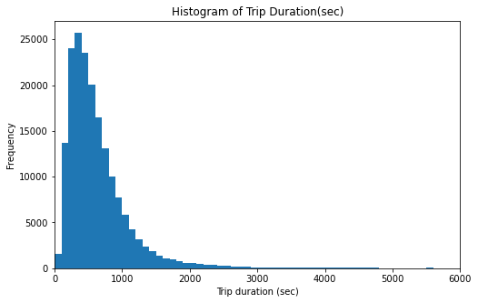

```python
# Histogram of trip duration in sec
bins = np.arange(0, df_cleaned['duration_sec'].max() + 100 , 100)
plt.figure(figsize=[8, 5])
plt.title('Histogram of Trip Duration(sec)')
plt.hist(df_cleaned["duration_sec"], bins = bins)
plt.xlabel('Trip duration (sec)')
plt.ylabel('Frequency')
plt.xlim((0, 6000))
plt.show();
```

### 2- Investigation of age of the members:

##### The age of each trip user is investigated to understand its variation. We used Histogram to devide the age of users into slots for better understanding of the data.

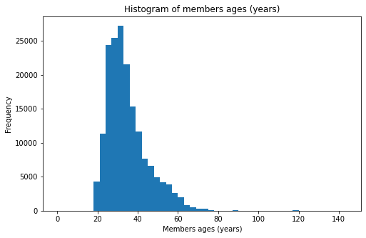

```python
# check the histogram of the members ages
bins = np.arange(0, df_cleaned['member_age'].max() + 5 , 3)
plt.figure(figsize=[8, 5])
plt.title('Histogram of members ages (years)')
plt.hist(df_cleaned["member_age"], bins=bins)
plt.xlabel('Members ages (years)')
plt.ylabel('Frequency')
plt.show();
```

### 4- Investigation of member genders:

##### The gender of each trip user is investigated to understand its variation. We used pie chart to illustrate the gender of users for better understanding of the data.

```python
# extract the gender to be analyize
member_gender = pd.DataFrame(df_cleaned["member_gender"].value_counts().reset_index())
member_gender
```

|  | index | member_gender |
| --- | --- | --- |
| 0 | Male | 130651 |
| 1 | Female | 40844 |
| 2 | Other | 3652 |

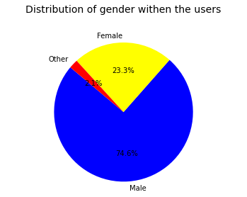

```python
# Data to plot using pie chart
labels = member_gender["index"]
sizes = member_gender["member_gender"]
colors = ['blue', 'yellow', 'red']
explode = (0, 0, 0)  # explode 1st slice
plt.title('Distribution of gender withen the users', fontsize=14, y=1.12)

# Plot
plt.pie(sizes, explode=explode, labels=labels, colors=colors,
autopct='%1.1f%%', shadow=False, startangle=140)

plt.axis('equal')
plt.show()
```

### Finding:

##### The most gender who use the app is Males.

### Most of the trips user males.

### 5- Investigation of start stations:

```python
# extract the start stations to be analyize
Start_stations = pd.DataFrame(df_cleaned["start_station_id"].value_counts().reset_index())
Start_stations = Start_stations.rename({'index': 'start_station_id', 'start_station_id': 'start_station_count'}, axis=1)
Start_stations['start_station_id'] = Start_stations['start_station_id'].astype('str')
Start_stations
```

|  | start_station_id | start_station_count |
| --- | --- | --- |
| 0 | 58.0 | 3904 |
| 1 | 67.0 | 3544 |
| 2 | 81.0 | 3052 |
| 3 | 21.0 | 2895 |
| 4 | 3.0 | 2760 |
| ... | ... | ... |
| 324 | 301.0 | 9 |
| 325 | 51.0 | 7 |
| 326 | 224.0 | 4 |
| 327 | 300.0 | 4 |
| 328 | 344.0 | 2 |

329 rows × 2 columns

```python
Start_stations.describe()
```

|  | start_station_count |
| --- | --- |
| count | 329.000000 |
| mean | 556.884498 |
| std | 580.872272 |
| min | 2.000000 |
| 25% | 158.000000 |
| 50% | 391.000000 |
| 75% | 772.000000 |
| max | 3904.000000 |

```python
# extract the start station to be analyize (choose highest 25% of the start stations)
Start_stations_highest_25 = Start_stations.loc[Start_stations['start_station_count'] >= 772]
Start_stations_highest_25
```

|  | start_station_id | start_station_count |
| --- | --- | --- |
| 0 | 58.0 | 3904 |
| 1 | 67.0 | 3544 |
| 2 | 81.0 | 3052 |
| 3 | 21.0 | 2895 |
| 4 | 3.0 | 2760 |
| ... | ... | ... |
| 79 | 70.0 | 790 |
| 80 | 26.0 | 782 |
| 81 | 129.0 | 781 |
| 82 | 42.0 | 772 |
| 83 | 139.0 | 772 |

84 rows × 2 columns

```python
# list the highest 25% of the start stations
Start_stations_highest_25.start_station_id.unique()
```

```
array(['58.0', '67.0', '81.0', '21.0', '3.0', '15.0', '30.0', '5.0',
       '22.0', '16.0', '6.0', '239.0', '243.0', '50.0', '66.0', '17.0',
       '27.0', '44.0', '90.0', '93.0', '23.0', '19.0', '245.0', '104.0',
       '61.0', '114.0', '126.0', '182.0', '350.0', '256.0', '36.0',
       '324.0', '24.0', '74.0', '60.0', '343.0', '321.0', '43.0', '130.0',
       '59.0', '80.0', '223.0', '20.0', '89.0', '134.0', '28.0', '176.0',
       '86.0', '11.0', '109.0', '296.0', '371.0', '78.0', '9.0', '323.0',
       '47.0', '349.0', '25.0', '64.0', '310.0', '284.0', '77.0', '377.0',
       '92.0', '49.0', '160.0', '368.0', '88.0', '7.0', '62.0', '364.0',
       '266.0', '112.0', '241.0', '253.0', '121.0', '14.0', '355.0',
       '10.0', '70.0', '26.0', '129.0', '42.0', '139.0'], dtype=object)
```

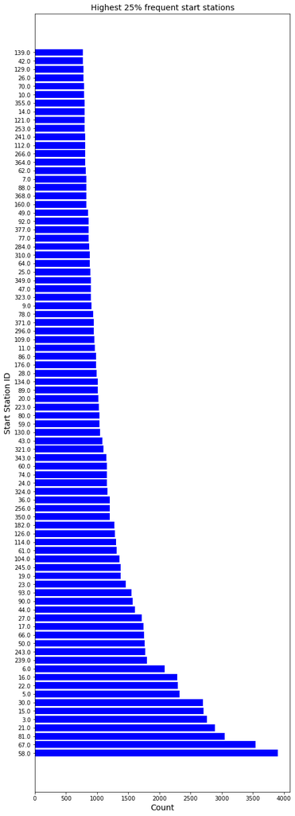

```python
# plot the end_stations_highest_25
plt.figure(figsize=[8, 25])
plt.barh(Start_stations_highest_25['start_station_id'], Start_stations_highest_25['start_station_count'], color='blue')
plt.title('Highest 25% frequent start stations', fontsize=14)
plt.xlabel('Count', fontsize=14)
plt.ylabel('Start Station ID', fontsize=14)
plt.show();
```

### The highst 25% most used start stations are:

#### '58.0', '67.0', '81.0', '21.0', '3.0', '15.0', '30.0', '5.0','22.0', '16.0', '6.0', '239.0', '243.0', '50.0', '66.0','17.0','27.0', '44.0', '90.0', '93.0', '23.0', '19.0', '245.0', '104.0','61.0', '114.0', '126.0', '182.0', '350.0', '256.0', '36.0','324.0', '24.0', '74.0', '60.0', '343.0', '321.0', '43.0', '130.0','59.0', '80.0', '223.0', '20.0', '89.0', '134.0', '28.0', '176.0','86.0', '11.0', '109.0', '296.0', '371.0', '78.0', '9.0', '323.0','47.0', '349.0', '25.0', '64.0', '310.0', '284.0', '77.0', '377.0','92.0', '49.0', '160.0', '368.0', '88.0', '7.0', '62.0', '364.0','266.0', '112.0', '241.0', '253.0', '121.0', '14.0', '355.0','10.0', '70.0', '26.0', '129.0', '42.0', '139.0'

### 6- Investigation of end stations:

```python
# extract the end stations to be analyize
end_stations = pd.DataFrame(df_cleaned["end_station_id"].value_counts().reset_index())
end_stations = end_stations.rename({'index': 'end_station_id', 'end_station_id': 'end_station_count'}, axis=1)
end_stations['end_station_id'] = end_stations['end_station_id'].astype('str')
end_stations
```

|  | end_station_id | end_station_count |
| --- | --- | --- |
| 0 | 67.0 | 4857 |
| 1 | 58.0 | 3973 |
| 2 | 21.0 | 3647 |
| 3 | 15.0 | 3368 |
| 4 | 3.0 | 2997 |
| ... | ... | ... |
| 324 | 51.0 | 9 |
| 325 | 300.0 | 7 |
| 326 | 224.0 | 6 |
| 327 | 344.0 | 6 |
| 328 | 301.0 | 5 |

329 rows × 2 columns

```python
# cheking end_stations
end_stations.describe()
```

|  | end_station_count |
| --- | --- |
| count | 329.000000 |
| mean | 556.884498 |
| std | 630.086245 |
| min | 5.000000 |
| 25% | 163.000000 |
| 50% | 374.000000 |
| 75% | 765.000000 |
| max | 4857.000000 |

```python
# extract the end station to be analyize (choose highest 25% of the end stations)
end_stations_highest_25 = end_stations.loc[end_stations['end_station_count'] >= 765]
end_stations_highest_25
```

|  | end_station_id | end_station_count |
| --- | --- | --- |
| 0 | 67.0 | 4857 |
| 1 | 58.0 | 3973 |
| 2 | 21.0 | 3647 |
| 3 | 15.0 | 3368 |
| 4 | 3.0 | 2997 |
| ... | ... | ... |
| 78 | 9.0 | 802 |
| 79 | 368.0 | 790 |
| 80 | 7.0 | 778 |
| 81 | 139.0 | 766 |
| 82 | 238.0 | 765 |

83 rows × 2 columns

```python
# list the highest 25% of the end stations
end_stations_highest_25.end_station_id.unique()
```

```
array(['67.0', '58.0', '21.0', '15.0', '3.0', '30.0', '81.0', '6.0',
       '5.0', '16.0', '22.0', '44.0', '239.0', '27.0', '50.0', '66.0',
       '17.0', '93.0', '90.0', '23.0', '182.0', '19.0', '245.0', '114.0',
       '350.0', '36.0', '61.0', '126.0', '104.0', '24.0', '74.0', '89.0',
       '243.0', '176.0', '321.0', '223.0', '324.0', '60.0', '43.0',
       '256.0', '371.0', '20.0', '88.0', '80.0', '130.0', '11.0', '134.0',
       '109.0', '343.0', '59.0', '10.0', '86.0', '28.0', '64.0', '296.0',
       '112.0', '310.0', '47.0', '349.0', '323.0', '14.0', '284.0',
       '77.0', '160.0', '364.0', '92.0', '266.0', '49.0', '241.0', '78.0',
       '62.0', '377.0', '26.0', '200.0', '121.0', '355.0', '129.0',
       '25.0', '9.0', '368.0', '7.0', '139.0', '238.0'], dtype=object)
```

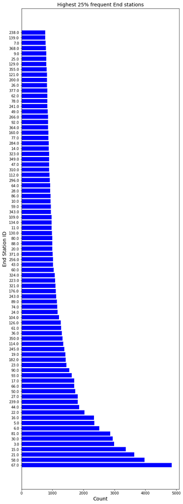

```python
# plot the end_stations_highest_25
plt.figure(figsize=[8, 25])
plt.barh(end_stations_highest_25['end_station_id'], end_stations_highest_25['end_station_count'], color='blue')
plt.title('Highest 25% frequent End stations', fontsize=14)
plt.xlabel('Count', fontsize=14)
plt.ylabel('End Station ID', fontsize=14)
plt.show();
```

#### '67.0', '58.0', '21.0', '15.0', '3.0', '30.0', '81.0', '6.0','5.0', '16.0', '22.0', '44.0', '239.0', '27.0', '50.0', '66.0','17.0', '93.0', '90.0', '23.0', '182.0', '19.0', '245.0', '114.0','350.0', '36.0', '61.0', '126.0', '104.0', '24.0', '74.0', '89.0','243.0', '176.0', '321.0', '223.0', '324.0', '60.0', '43.0','256.0', '371.0', '20.0', '88.0', '80.0', '130.0', '11.0', '134.0','109.0', '343.0', '59.0', '10.0', '86.0', '28.0', '64.0', '296.0', '112.0', '310.0', '47.0', '349.0', '323.0', '14.0', '284.0','77.0', '160.0', '364.0', '92.0', '266.0', '49.0', '241.0', '78.0','62.0', '377.0', '26.0', '200.0', '121.0', '355.0', '129.0','25.0', '9.0', '368.0', '7.0', '139.0', '238.0'

### 7- Investigation of user type:

##### For all trips, which are the most common user type?

```python
# extract the user type to be analyize
user_type = pd.DataFrame(df_cleaned["user_type"].value_counts().reset_index())
user_type
```

|  | index | user_type |
| --- | --- | --- |
| 0 | Subscriber | 163544 |
| 1 | Customer | 19868 |

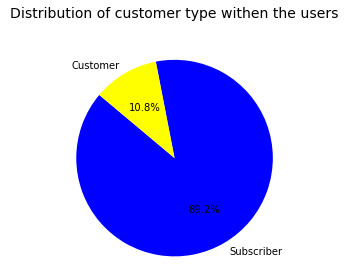

```python
# Data to plot using pie chart
labels = user_type["index"]
sizes = user_type["user_type"]
colors = ['blue', 'yellow']
explode = (0, 0)  # explode 1st slice
plt.title('Distribution of customer type withen the users', fontsize=14, y=1.12)

# Plot
plt.pie(sizes, explode=explode, labels=labels, colors=colors,
autopct='%1.1f%%', shadow=False, startangle=140)

plt.axis('equal')
plt.show()
```

### The most user type who use the app is subscribers.

### 8- Investigation of bike_share_for_all_trip:

```python
# extract the bike_share_for_all_trip to be analyize
bike_share_for_all_trip = pd.DataFrame(df_cleaned["bike_share_for_all_trip"].value_counts().reset_index())
bike_share_for_all_trip
```

|  | index | bike_share_for_all_trip |
| --- | --- | --- |
| 0 | No | 166053 |
| 1 | Yes | 17359 |

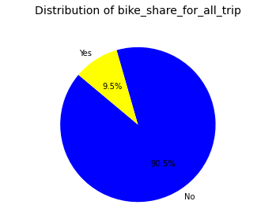

```python
# Data to plot using pie chart
labels = bike_share_for_all_trip["index"]
sizes = bike_share_for_all_trip["bike_share_for_all_trip"]
colors = ['blue', 'yellow']
explode = (0, 0)  # explode 1st slice
plt.title('Distribution of bike_share_for_all_trip', fontsize=14, y=1.12)

# Plot
plt.pie(sizes, explode=explode, labels=labels, colors=colors,
autopct='%1.1f%%', shadow=False, startangle=140)

plt.axis('equal')
plt.show()
```

### Finding:

##### Mostly, not bike_share_for_all_trip.

### Discuss the distribution(s) of your variable(s) of interest. Were there any unusual points? Did you need to perform any transformations?

> No, no need for transformations.

### Of the features you investigated, were there any unusual distributions? Did you perform any operations on the data to tidy, adjust, or change the form of the data? If so, why did you do this?

> Yes, to caluculate the members ages and to make the start and end stations datatype as object

## Bivariate Exploration

> In this section, investigate relationships between pairs of variables in your data. Make sure the variables that you cover here have been introduced in some fashion in the previous section (univariate exploration).

### 8- Investigation of correlations between the trip duration and the age of members:

##### For all trips, Is the age of the user have effect on the duration of the trip? What is the nature of this effect?

```python
correlation = df_cleaned[["duration_sec", 'member_age']]
correlation
```

|  | duration_sec | member_age |
| --- | --- | --- |
| 0 | 52185 | 35.0 |
| 1 | 42521 | NaN |
| 2 | 61854 | 47.0 |
| 3 | 36490 | 30.0 |
| 4 | 1585 | 45.0 |
| ... | ... | ... |
| 183407 | 480 | 23.0 |
| 183408 | 313 | 35.0 |
| 183409 | 141 | 29.0 |
| 183410 | 139 | 31.0 |
| 183411 | 271 | 30.0 |

183412 rows × 2 columns

```python
# drop nan values
correlation.dropna()
correlation
```

|  | duration_sec | member_age |
| --- | --- | --- |
| 0 | 52185 | 35.0 |
| 1 | 42521 | NaN |
| 2 | 61854 | 47.0 |
| 3 | 36490 | 30.0 |
| 4 | 1585 | 45.0 |
| ... | ... | ... |
| 183407 | 480 | 23.0 |
| 183408 | 313 | 35.0 |
| 183409 | 141 | 29.0 |
| 183410 | 139 | 31.0 |
| 183411 | 271 | 30.0 |

183412 rows × 2 columns

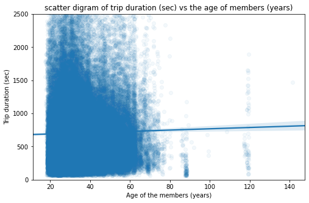

```python
# scatter digram of trip duration in sec vs the age of members
plt.figure(figsize=[8, 5])
plt.title('scatter digram of trip duration (sec) vs the age of members (years)')
sb.regplot(x=correlation["member_age"], y=correlation["duration_sec"], truncate=False, x_jitter=0.5, scatter_kws={'alpha':1/20})
plt.xlabel('Age of the members (years)')
plt.ylabel('Trip duration (sec)')
plt.ylim([0,2500])
plt.show();
```

```python
# create sample to make the plot more understandable
np.random.seed(50)
data_sample_corr = np.random.choice(correlation.shape[0], 500, replace=False)
sample_corr = correlation.loc[data_sample_corr]
```

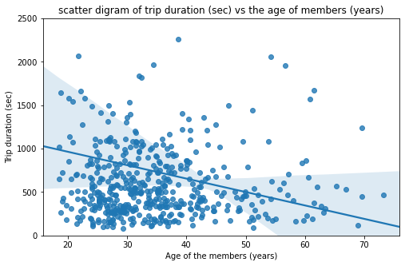

```python
# scatter digram of trip duration in sec vs the age of members (less points)
plt.figure(figsize=[8, 5])
plt.title('scatter digram of trip duration (sec) vs the age of members (years)')
sb.regplot(x=sample_corr["member_age"], y=sample_corr["duration_sec"], truncate=False, x_jitter=0.5)
plt.xlabel('Age of the members (years)')
plt.ylabel('Trip duration (sec)')
plt.ylim([0,2500])
plt.show();
```

### 9- Investigation of correlations between the trip duration and the gender of users:

##### For all trips, Is the gender of the user have effect on the duration of the trip? What is the nature of this effect?

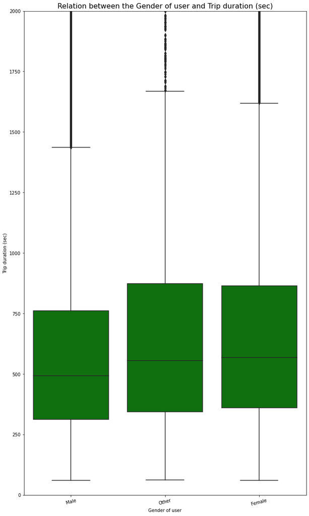

```python
# use box plot
plt.figure(figsize=[25, 20])
plt.subplot(1, 2, 2)
sb.boxplot(data=df_cleaned, x='member_gender', y='duration_sec', color='green')
plt.title('Relation between the Gender of user and Trip duration (sec)', fontsize=16, y=1.0)
plt.xlabel('Gender of user')
plt.ylabel('Trip duration (sec)')
plt.xticks(rotation=15);
plt.ylim([0,2000]);
```

### The trip duration tend to be a little longer for femails than males (males tend to be faster)

### 10- Investigation of correlations between the user type and user age:

##### For all trips, Is the age of the user have effect on the selecting the user type of the trip? What is the nature of this effect?

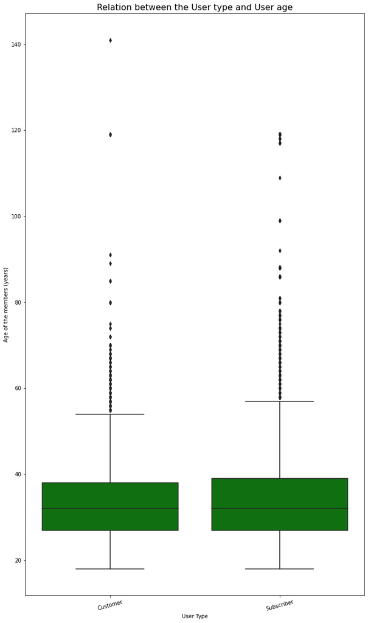

```python
# use box plot
plt.figure(figsize=[25, 20])
plt.subplot(1, 2, 2)
sb.boxplot(data=df_cleaned, x='user_type', y='member_age', color='green')
plt.title('Relation between the User type and User age', fontsize=16, y=1.0)
plt.xlabel('User Type')
plt.ylabel('Age of the members (years)')
plt.xticks(rotation=15);
```

### The age of the user have no effect on the user type.

### 11- Investigation of correlations between the user gender and user type:

##### For all trips, Is the gender of the user have effect on the selecting the user type of the trip? What is the nature of this effect?

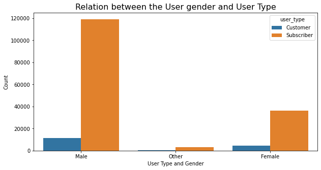

```python
# Clustered bar chart
plt.figure(figsize=[10, 5])
sb.countplot(data = df_cleaned, x = 'member_gender', hue = 'user_type')
plt.title('Relation between the User gender and User Type', fontsize=16, y=1.0)
plt.xlabel('User Type and Gender')
plt.ylabel('Count')
```

### 12- Investigation of correlations between the user gender and user age:

##### For all trips, Is the gender of the user and the user age of the trip are linked together? What is the nature of this effect?

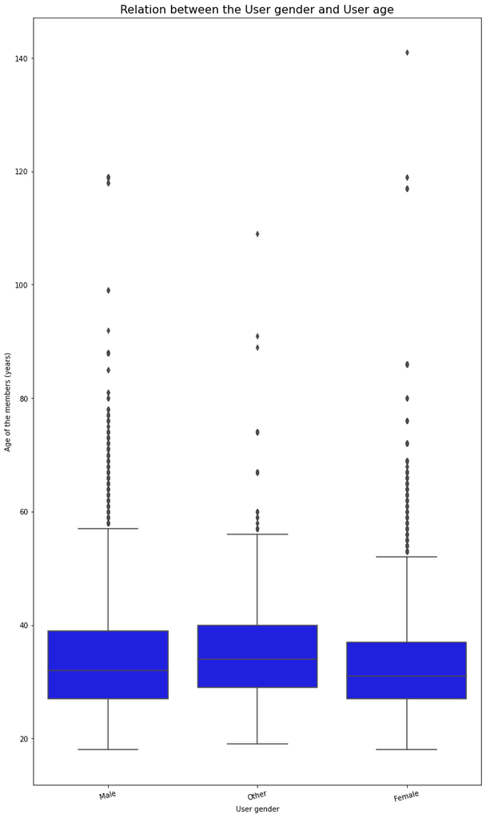

```python
# Boxplot
plt.figure(figsize=[25, 20])
plt.subplot(1, 2, 2)
sb.boxplot(data=df_cleaned, x='member_gender', y='member_age', color='blue')
plt.title('Relation between the User gender and User age', fontsize=16, y=1.0)
plt.xlabel('User gender')
plt.ylabel('Age of the members (years)')
plt.xticks(rotation=15);
```

## Multivariate Exploration

> Create plots of three or more variables to investigate your data even further. Make sure that your investigations are justified, and follow from your work in the previous sections.

### 13- Investigation of Age, gender of the users and the trip duration:

##### Is the age and gender of the user have effect on the trip duration? What is the nature of this effect?

```python
# create sample
np.random.seed(50)
data_sample = np.random.choice(df_cleaned.shape[0], 500, replace=False)
sample = df_cleaned.loc[data_sample]
```

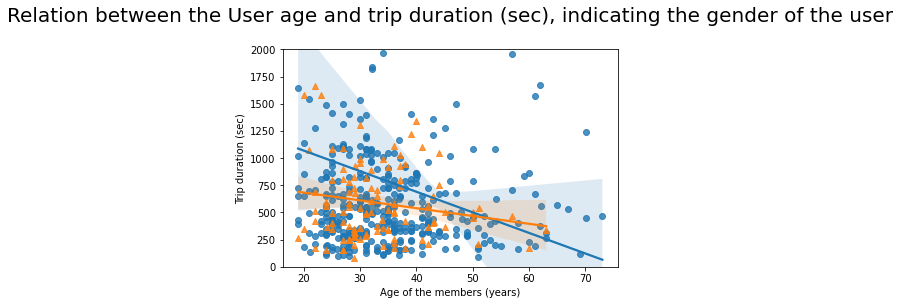

```python
# Create markers for gender and plot the scatter plot
gender_marker = [['Male', 'o'], ['Female', '^']]

for gender, marker in gender_marker:
    plot_data = sample.loc[sample['member_gender'] == gender]
    sb.regplot(data = plot_data, x = 'member_age', y = 'duration_sec', x_jitter = 0.04, marker = marker)

plt.title('Relation between the User age and trip duration (sec), indicating the gender of the user', fontsize=20, y=1.1)
plt.xlabel('Age of the members (years)', fontsize=10)
plt.ylabel('Trip duration (sec)', fontsize=10)
plt.ylim([0,2000]);
```

### 13- Investigation of user type, gender of the users and the trip duration:

##### Is the user type and gender of the user have effect on the trip duration? What is the nature of this effect?

```python
df_cleaned.columns
```

```
Index(['duration_sec', 'start_time', 'end_time', 'start_station_id',
       'start_station_name', 'start_station_latitude',
       'start_station_longitude', 'end_station_id', 'end_station_name',
       'end_station_latitude', 'end_station_longitude', 'bike_id', 'user_type',
       'member_birth_year', 'member_gender', 'bike_share_for_all_trip',
       'member_age'],
      dtype='object')
```

[output not shown]

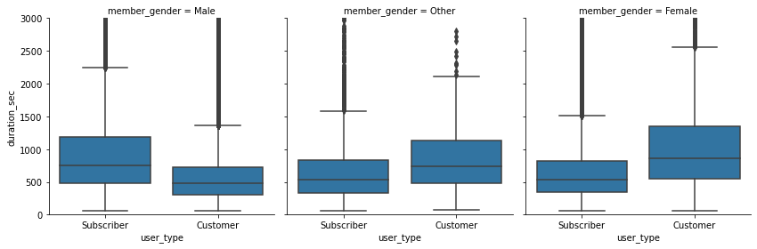

```python
g = sb.FacetGrid(data = df_cleaned, col = 'member_gender', size = 4)
g.map(sb.boxplot, 'user_type', 'duration_sec')
plt.ylim([0,3000]);
```

### Subcribers males take longer trip durations than females, while the female customers take longer trip durations than males

### 14- Investigation of user type, gender of the users and the start time of the trip:

##### Is the user type and gender of the user have effect on the trip start time? What is the nature of this effect?

```python
# create new dataframe to preserve the original data
data = df_cleaned
# create column to show the time in hour format
data["Hour"] = data["start_time"].dt.hour
data
```

|  | duration_sec | start_time | end_time | start_station_id | start_station_name | start_station_latitude | start_station_longitude | end_station_id | end_station_name | end_station_latitude | end_station_longitude | bike_id | user_type | member_birth_year | member_gender | bike_share_for_all_trip | member_age | Hour |
| --- | --- | --- | --- | --- | --- | --- | --- | --- | --- | --- | --- | --- | --- | --- | --- | --- | --- | --- |
| 0 | 52185 | 2019-02-28 17:32:10.145 | 2019-03-01 08:01:55.975 | 21 | Montgomery St BART Station (Market St at 2nd St) | 37.789625 | -122.400811 | 13 | Commercial St at Montgomery St | 37.794231 | -122.402923 | 4902 | Customer | 1984.0 | Male | No | 35.0 | 17 |
| 1 | 42521 | 2019-02-28 18:53:21.789 | 2019-03-01 06:42:03.056 | 23 | The Embarcadero at Steuart St | 37.791464 | -122.391034 | 81 | Berry St at 4th St | 37.775880 | -122.393170 | 2535 | Customer | NaN | NaN | No | NaN | 18 |
| 2 | 61854 | 2019-02-28 12:13:13.218 | 2019-03-01 05:24:08.146 | 86 | Market St at Dolores St | 37.769305 | -122.426826 | 3 | Powell St BART Station (Market St at 4th St) | 37.786375 | -122.404904 | 5905 | Customer | 1972.0 | Male | No | 47.0 | 12 |
| 3 | 36490 | 2019-02-28 17:54:26.010 | 2019-03-01 04:02:36.842 | 375 | Grove St at Masonic Ave | 37.774836 | -122.446546 | 70 | Central Ave at Fell St | 37.773311 | -122.444293 | 6638 | Subscriber | 1989.0 | Other | No | 30.0 | 17 |
| 4 | 1585 | 2019-02-28 23:54:18.549 | 2019-03-01 00:20:44.074 | 7 | Frank H Ogawa Plaza | 37.804562 | -122.271738 | 222 | 10th Ave at E 15th St | 37.792714 | -122.248780 | 4898 | Subscriber | 1974.0 | Male | Yes | 45.0 | 23 |
| ... | ... | ... | ... | ... | ... | ... | ... | ... | ... | ... | ... | ... | ... | ... | ... | ... | ... | ... |
| 183407 | 480 | 2019-02-01 00:04:49.724 | 2019-02-01 00:12:50.034 | 27 | Beale St at Harrison St | 37.788059 | -122.391865 | 324 | Union Square (Powell St at Post St) | 37.788300 | -122.408531 | 4832 | Subscriber | 1996.0 | Male | No | 23.0 | 0 |
| 183408 | 313 | 2019-02-01 00:05:34.744 | 2019-02-01 00:10:48.502 | 21 | Montgomery St BART Station (Market St at 2nd St) | 37.789625 | -122.400811 | 66 | 3rd St at Townsend St | 37.778742 | -122.392741 | 4960 | Subscriber | 1984.0 | Male | No | 35.0 | 0 |
| 183409 | 141 | 2019-02-01 00:06:05.549 | 2019-02-01 00:08:27.220 | 278 | The Alameda at Bush St | 37.331932 | -121.904888 | 277 | Morrison Ave at Julian St | 37.333658 | -121.908586 | 3824 | Subscriber | 1990.0 | Male | Yes | 29.0 | 0 |
| 183410 | 139 | 2019-02-01 00:05:34.360 | 2019-02-01 00:07:54.287 | 220 | San Pablo Ave at MLK Jr Way | 37.811351 | -122.273422 | 216 | San Pablo Ave at 27th St | 37.817827 | -122.275698 | 5095 | Subscriber | 1988.0 | Male | No | 31.0 | 0 |
| 183411 | 271 | 2019-02-01 00:00:20.636 | 2019-02-01 00:04:52.058 | 24 | Spear St at Folsom St | 37.789677 | -122.390428 | 37 | 2nd St at Folsom St | 37.785000 | -122.395936 | 1057 | Subscriber | 1989.0 | Male | No | 30.0 | 0 |

183412 rows × 18 columns

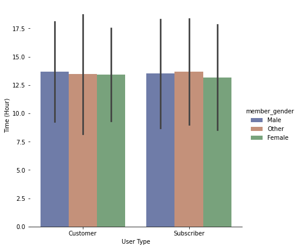

```python
# Draw a nested barplot by species and sex
g = sb.catplot(
    data=data, kind="bar",
    x='user_type', y="Hour", hue="member_gender",
    ci="sd", palette="dark", alpha=.6, height=6
)
g.despine(left=True)
g.set_axis_labels("User Type", "Time (Hour)");
```

### Were there any interesting or surprising interactions between features?

> At the end of your report, make sure that you export the notebook as an html file from the `File > Download as... > HTML` menu. Make sure you keep track of where the exported file goes, so you can put it in the same folder as this notebook for project submission. Also, make sure you remove all of the quote-formatted guide notes like this one before you finish your report!